# Project: Investigate churn

- Visual data inspection
- Data cleaning and prep
- Exploratory Data Analysis
- Model Selection
- Select Model Business Implications

```python
# load necessary packages
import pandas as pd
import numpy as np
import datetime as dt
import matplotlib.pyplot as plt
import statsmodels.api as sm
from statsmodels.stats.outliers_influence import variance_inflation_factor
from sklearn.model_selection import train_test_split
from sklearn.ensemble import RandomForestClassifier
from sklearn import metrics
from sklearn.metrics import classification_report, accuracy_score, confusion_matrix, RocCurveDisplay
from sklearn.linear_model import LogisticRegression
from sklearn.inspection import permutation_importance
import scikitplot as skplt
%matplotlib inline
import seaborn as sns
sns.set(rc={'figure.figsize':(18.7,14.27)})
```

```python
# load datasets
churn_df = pd.read_csv('/Users/chrismorehouse/Downloads/Churn_Dataset.csv')
```

## Visual data inspection

> Here I will dive into the data and get a sense for how it is formatted, what might be missing, and what will need to be cleaned up

```python
# visually inspecting what the data looks like
churn_df.head()
```

|  | AccountID | Account_Age | Seats | Paid_status | boards_last_30_days | projects_last_30_days | DAU_avg_last_30_days | integrations_count | Integrations_names | Templates_last_30_days |
| --- | --- | --- | --- | --- | --- | --- | --- | --- | --- | --- |
| 0 | 4505926 | 122 | 18 | Paying | 244 | 14 | 13 | 5 | Google, Slack, Zapier, Azure Cards, MS Team | 22 |
| 1 | 1005807 | 33 | 1 | Churned | 49 | 7 | 1 | 4 | Google, Jira, Slack, Dropbox | 36 |
| 2 | 6546087 | 31 | 44 | Paying | 46 | 32 | 38 | 4 | Slack, Zapier, MS Team, Azure Cards | 77 |
| 3 | 8471398 | 64 | 20 | Paying | 160 | 87 | 14 | 3 | Jira, Slack, Zapier | 44 |
| 4 | 2476200 | 87 | 58 | Paying | 87 | 32 | 49 | 1 | Zapier | 98 |

```python
# checking the data types and number of entries per row
churn_df.info()
```

```
<class 'pandas.core.frame.DataFrame'>
RangeIndex: 2000 entries, 0 to 1999
Data columns (total 10 columns):
 #   Column                  Non-Null Count  Dtype
---  ------                  --------------  -----
 0   AccountID               2000 non-null   int64
 1   Account_Age             2000 non-null   int64
 2   Seats                   2000 non-null   int64
 3   Paid_status             2000 non-null   object
 4   boards_last_30_days     2000 non-null   int64
 5   projects_last_30_days   2000 non-null   int64
 6   DAU_avg_last_30_days    2000 non-null   int64
 7   integrations_count      2000 non-null   int64
 8   Integrations_names      1621 non-null   object
 9   Templates_last_30_days  2000 non-null   int64
dtypes: int64(8), object(2)
memory usage: 156.4+ KB
```

```python
churn_df.Integrations_names.unique()
```

```
array(['Google, Slack, Zapier, Azure Cards, MS Team',
       'Google, Jira, Slack, Dropbox',
       'Slack, Zapier, MS Team, Azure Cards', 'Jira, Slack, Zapier',
       'Zapier', 'MS Team, Azure Cards', nan,
       'MS Team, Azure Cards, Dropbox',
       'Jira, Google, Slack, Zapier, Dropbox', 'Jira, Slack',
       'Azure Cards', 'Dropbox', 'Jira, Zapier', 'Jira',
       'Dropbox, Slack, Google', 'Slack', 'MS Team', 'Google'],
      dtype=object)
```

```python
col_list = list(churn_df.columns)
for col in col_list:
    num = churn_df[col].nunique()
    print("Num of unique {} :{}".format(col, num))
```

```
Num of unique AccountID :2000
Num of unique Account_Age :325
Num of unique Seats :76
Num of unique Paid_status :2
Num of unique boards_last_30_days :396
Num of unique projects_last_30_days :269
Num of unique DAU_avg_last_30_days :52
Num of unique integrations_count :6
Num of unique Integrations_names :17
Num of unique Templates_last_30_days :101
```

```python
num = len(pd.unique(churn_df['AccountID']))
print("Num of unique accounts :",
      num)
```

```
Num of unique accounts : 2000
```

```python
# Review for any missing data, outliers, or strange values
churn_df.describe()
```

|  | AccountID | Account_Age | Seats | boards_last_30_days | projects_last_30_days | DAU_avg_last_30_days | integrations_count | Templates_last_30_days |
| --- | --- | --- | --- | --- | --- | --- | --- | --- |
| count | 2.000000e+03 | 2000.000000 | 2000.00000 | 2000.000000 | 2000.000000 | 2000.000000 | 2000.000000 | 2000.000000 |
| mean | 5.057934e+06 | 100.195000 | 33.83000 | 107.242000 | 52.810500 | 21.144500 | 2.437500 | 50.453000 |
| std | 2.314520e+06 | 82.610455 | 23.32248 | 119.667391 | 74.486393 | 14.261603 | 1.743449 | 29.765093 |
| min | 1.001950e+06 | 1.000000 | 0.00000 | 0.000000 | 0.000000 | 0.000000 | 0.000000 | 0.000000 |
| 25% | 3.025739e+06 | 35.000000 | 12.00000 | 19.000000 | 4.000000 | 7.000000 | 1.000000 | 24.000000 |
| 50% | 5.146980e+06 | 78.000000 | 32.00000 | 62.000000 | 24.000000 | 22.000000 | 2.000000 | 51.000000 |
| 75% | 7.050892e+06 | 145.000000 | 55.00000 | 156.000000 | 71.000000 | 33.000000 | 4.000000 | 77.000000 |
| max | 8.997315e+06 | 395.000000 | 75.00000 | 717.000000 | 518.000000 | 51.000000 | 5.000000 | 100.000000 |

```python
churn_df.isna().any()
```

```
AccountID                 False
Account_Age               False
Seats                     False
Paid_status               False
boards_last_30_days       False
projects_last_30_days     False
DAU_avg_last_30_days      False
integrations_count        False
Integrations_names         True
Templates_last_30_days    False
dtype: bool
```

## Data cleaning and prep

```python
# Create dummy variables for integration names
churn_df_copy = churn_df.copy()
churn_df_copy.drop(columns=['AccountID'],inplace=True)
integration_dummy = churn_df_copy['Integrations_names'].str.get_dummies(', ').add_prefix('Integrations_')
churn_df_copy = pd.concat([churn_df_copy, integration_dummy], axis = 1).drop('Integrations_names', 1)
```

```python
# 1/0 classification for paid status
# 1 will indicate churn
churn_dummy = churn_df_copy['Paid_status'].str.get_dummies()
churn_df_copy = pd.concat([churn_df_copy, churn_dummy], axis = 1).drop('Paid_status', 1)
churn_df_copy.drop(columns=['Paying'],inplace=True)
```

```python
churn_df_copy.isna().any()
```

```
Account_Age                 False
Seats                       False
boards_last_30_days         False
projects_last_30_days       False
DAU_avg_last_30_days        False
integrations_count          False
Templates_last_30_days      False
Integrations_Azure Cards    False
Integrations_Dropbox        False
Integrations_Google         False
Integrations_Jira           False
Integrations_MS Team        False
Integrations_Slack          False
Integrations_Zapier         False
Churned                     False
dtype: bool
```

## Exploratory Data Analysis

> Setting up visualizations for various cuts of the data to check for patterns to inform business decisions and model building

```python
sns.set_style("whitegrid")
sns.set_palette('Paired')
```

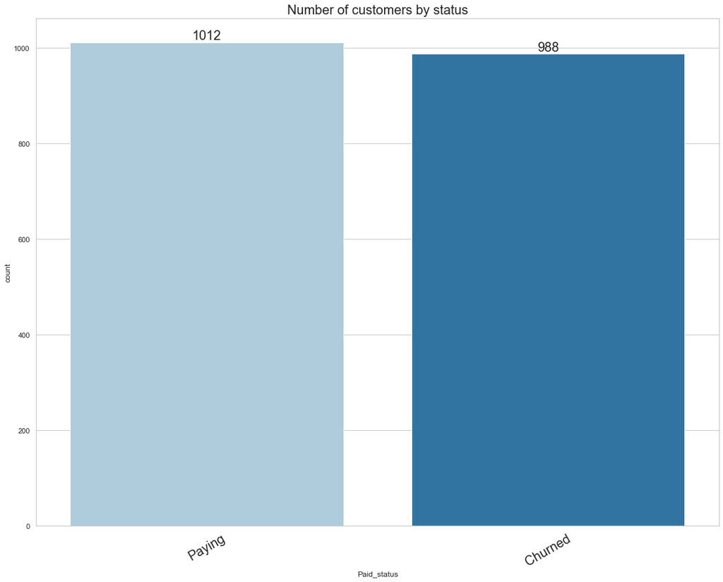

```python
ax = sns.countplot(x="Paid_status",
                   data=churn_df)
ax.set_xticklabels(ax.get_xticklabels(),rotation = 30, fontsize = 20)
ax.bar_label(ax.containers[0], fontsize = 20)
ax.set_title('Number of customers by status', fontsize = 20)
```

Almost perfectly balanced sample

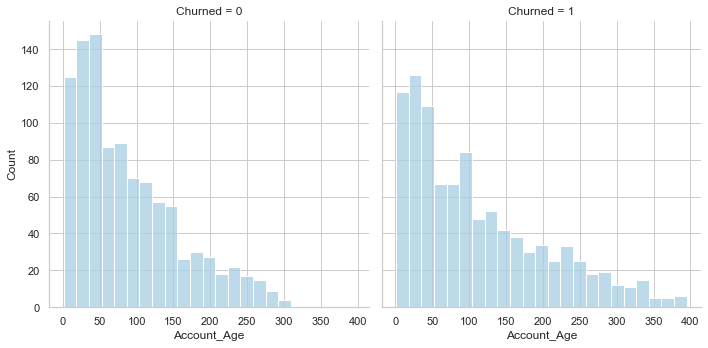

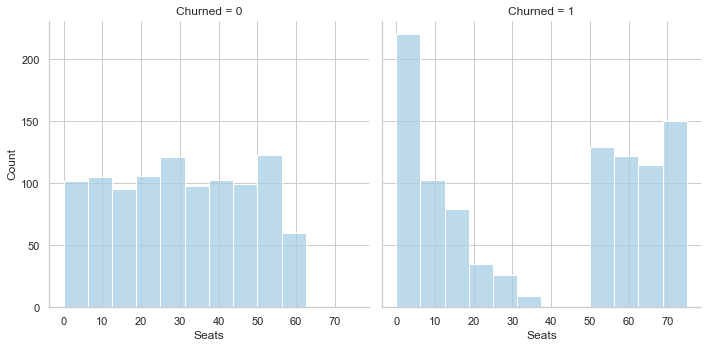

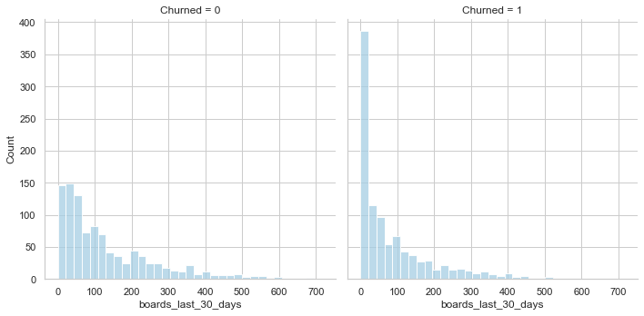

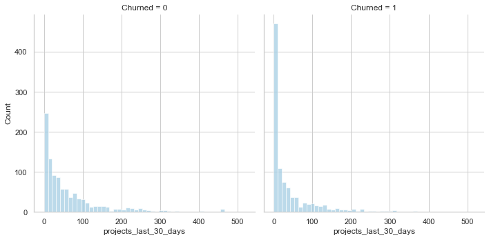

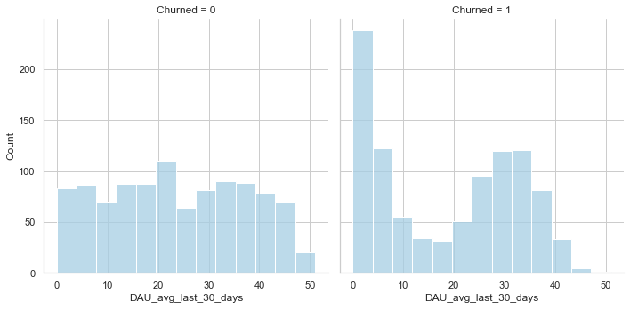

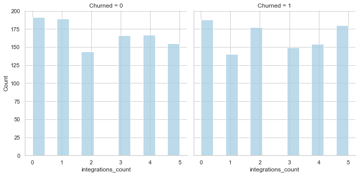

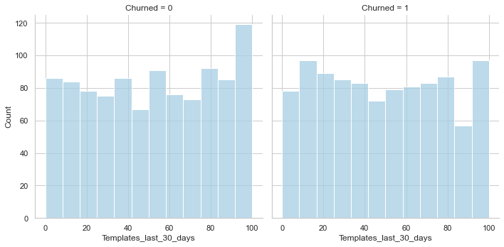

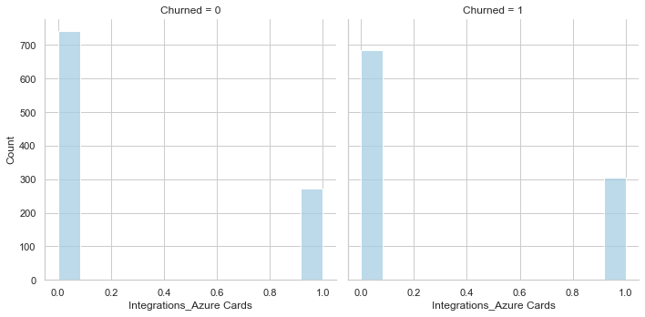

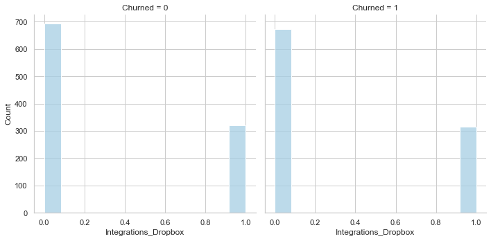

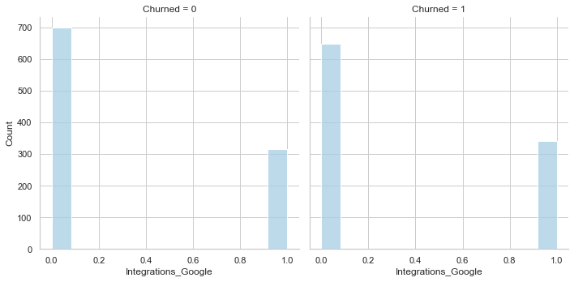

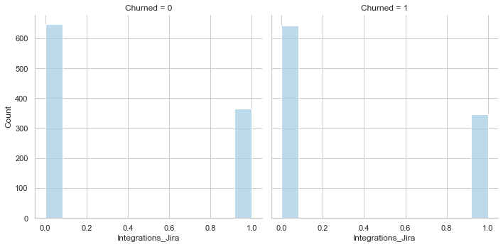

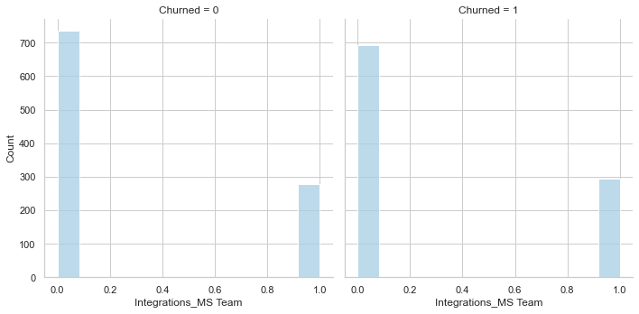

[2 more figures not shown]

```python
#Histograms comparing churned and paying customers and their attributes
col_list = list(churn_df_copy.columns)
col_list.remove('Churned')
for col in col_list:
    sns.displot(churn_df_copy, x=col, col="Churned")
```

```python
churn_df_copy.info()
```

```
<class 'pandas.core.frame.DataFrame'>
RangeIndex: 2000 entries, 0 to 1999
Data columns (total 15 columns):
 #   Column                    Non-Null Count  Dtype
---  ------                    --------------  -----
 0   Account_Age               2000 non-null   int64
 1   Seats                     2000 non-null   int64
 2   boards_last_30_days       2000 non-null   int64
 3   projects_last_30_days     2000 non-null   int64
 4   DAU_avg_last_30_days      2000 non-null   int64
 5   integrations_count        2000 non-null   int64
 6   Templates_last_30_days    2000 non-null   int64
 7   Integrations_Azure Cards  2000 non-null   int64
 8   Integrations_Dropbox      2000 non-null   int64
 9   Integrations_Google       2000 non-null   int64
 10  Integrations_Jira         2000 non-null   int64
 11  Integrations_MS Team      2000 non-null   int64
 12  Integrations_Slack        2000 non-null   int64
 13  Integrations_Zapier       2000 non-null   int64
 14  Churned                   2000 non-null   int64
dtypes: int64(15)
memory usage: 234.5 KB
```

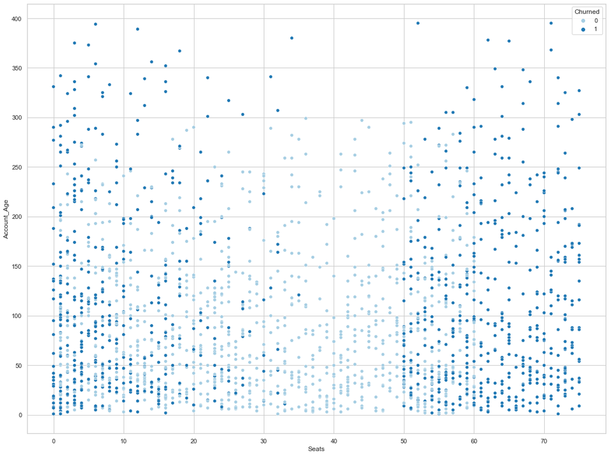

```python
sns.scatterplot(data=churn_df_copy, x="Seats", y="Account_Age", hue="Churned")
```

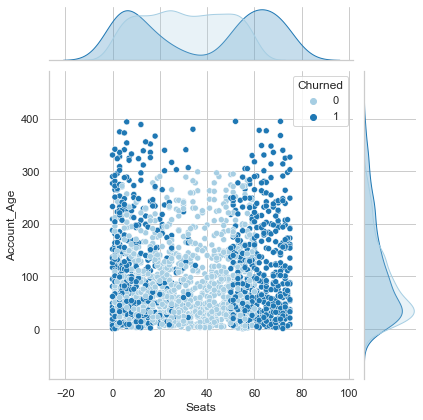

```python
sns.jointplot(data=churn_df_copy, x="Seats", y="Account_Age", hue="Churned")
```

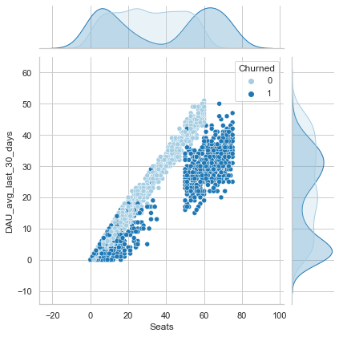

```python
sns.jointplot(data=churn_df_copy, x="Seats", y="DAU_avg_last_30_days", hue="Churned")
```

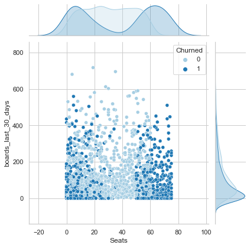

```python
sns.jointplot(data=churn_df_copy, x="Seats", y="boards_last_30_days", hue="Churned")
```

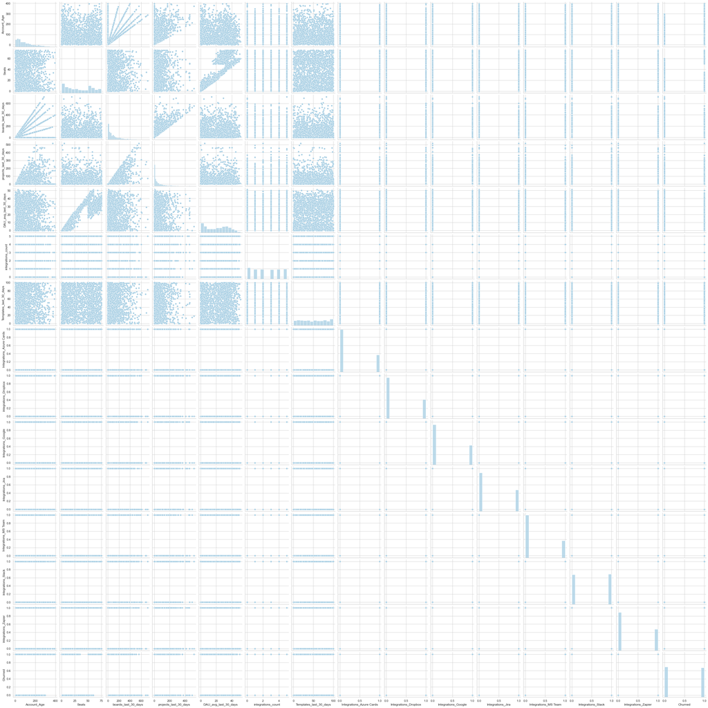

```python
# Pair plots to help spot correlations between variables
sns.pairplot(churn_df_copy)
```

[output not shown]

[output cut: 63 more lines]

[output not shown]

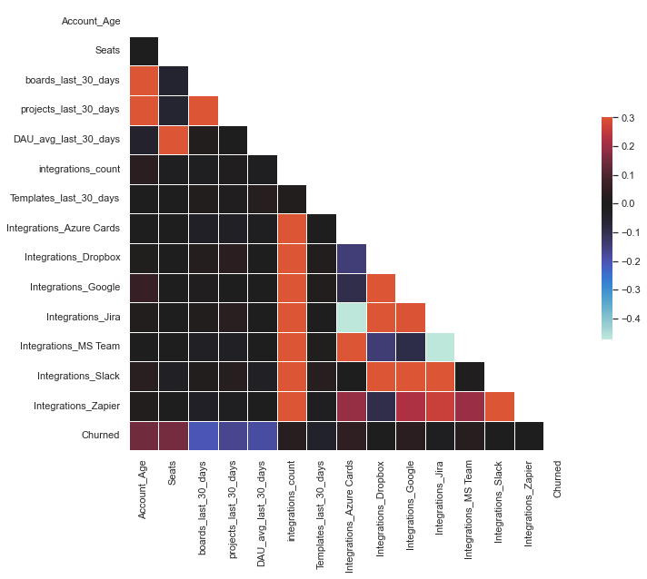

```python
# Correlation matrix
corr = churn_df_copy.corr()
print(corr)
mask = np.triu(np.ones_like(corr, dtype=bool))
f, ax = plt.subplots(figsize=(11, 9))
sns.heatmap(corr, mask=mask, vmax=.3, center=0,
            square=True, linewidths=.5, cbar_kws={"shrink": .5})
```

There looks to be some correlation between integration types and usage stats (DAU vs Seats and Boards vs Projects)

```python
# Checking Variance Inflation Factor to check for variable multicollinearity
X = churn_df_copy.drop(['Churned'], axis=1)
y = churn_df_copy['Churned']
X = sm.add_constant(X)
# Variance Inflation Factor (VIF)
pd.DataFrame({'variables':X.columns[1:], 'VIF':[variance_inflation_factor(X.values, i+1) for i in range(len(X.columns[1:]))]})
```

|  | variables | VIF |
| --- | --- | --- |
| 0 | Account_Age | 1.910538 |
| 1 | Seats | 5.328353 |
| 2 | boards_last_30_days | 3.264756 |
| 3 | projects_last_30_days | 2.414500 |
| 4 | DAU_avg_last_30_days | 5.331882 |
| 5 | integrations_count | inf |
| 6 | Templates_last_30_days | 1.004259 |
| 7 | Integrations_Azure Cards | inf |
| 8 | Integrations_Dropbox | inf |
| 9 | Integrations_Google | inf |
| 10 | Integrations_Jira | inf |
| 11 | Integrations_MS Team | inf |
| 12 | Integrations_Slack | inf |
| 13 | Integrations_Zapier | inf |

There seems to be a high indication of correlation given VIF scores for integration types. First I will run a model with all of these variables to see how the model performs

## Model Selection

```python
# Split test and train sets
X = churn_df_copy.drop(['Churned'], axis=1)
y = churn_df_copy['Churned']
X_train, X_test, y_train, y_test = train_test_split(X, y, test_size = 0.25, random_state = 0)

print('Training Features Shape:', X_train.shape)
print('Training Labels Shape:', y_train.shape)
print('Testing Features Shape:', X_test.shape)
print('Testing Labels Shape:', y_test.shape)
```

```
Training Features Shape: (1500, 14)
Training Labels Shape: (1500,)
Testing Features Shape: (500, 14)
Testing Labels Shape: (500,)
```

```python
# Random forest classifier
classifier = RandomForestClassifier(n_estimators=200, random_state=0)
classifier.fit(X_train, y_train)
predictions = classifier.predict(X_test)
print(classification_report(y_test,predictions ))
print(accuracy_score(y_test, predictions ))
```

```
              precision    recall  f1-score   support

           0       0.89      0.91      0.90       245
           1       0.91      0.89      0.90       255

    accuracy                           0.90       500
   macro avg       0.90      0.90      0.90       500
weighted avg       0.90      0.90      0.90       500

0.9
```

```python
logreg=LogisticRegression()
logreg.fit(X_train,y_train)
prediction_logreg=logreg.predict(X_test)
print(classification_report(y_test,prediction_logreg ))
print(accuracy_score(y_test, prediction_logreg ))
```

```
              precision    recall  f1-score   support

           0       0.86      0.90      0.88       245
           1       0.90      0.85      0.88       255

    accuracy                           0.88       500
   macro avg       0.88      0.88      0.88       500
weighted avg       0.88      0.88      0.88       500

0.876
```

The random forest model beats the logistic regression model on all classification metrics from the classification_report() function

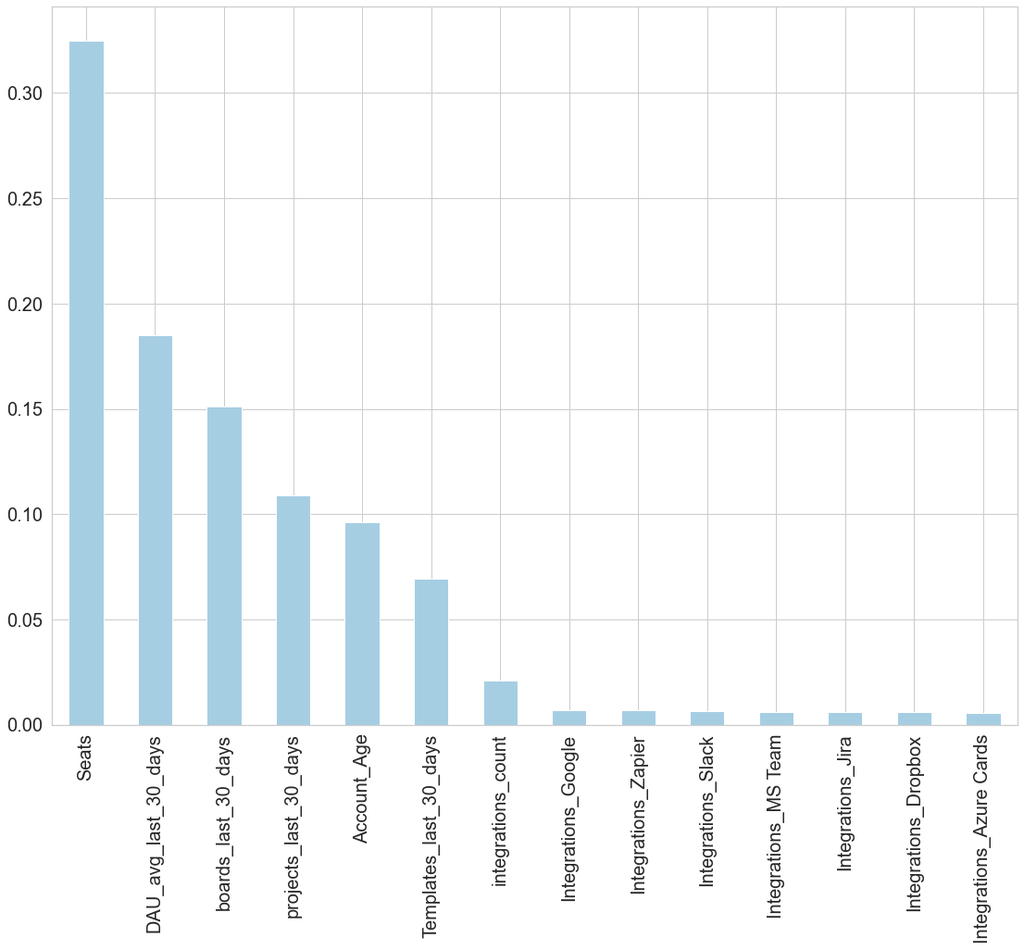

```python
# Checking feature importance for the random forest model
feat_importances = pd.Series(classifier.feature_importances_, index=X.columns)
plt.xticks(fontsize=20)
plt.yticks(fontsize=20)
feat_importances.nlargest(15).plot(kind='bar')
```

As indicated above, the integration types were likely going to be a drag on the model given their correlation. They seem to have little impact on the model and will be removed below and the random forest model will be rerun

```python
churn_df_copy_no_ints = churn_df.drop(columns=['AccountID','Integrations_names'])
churn_dummy = churn_df_copy_no_ints['Paid_status'].str.get_dummies()
churn_df_copy_no_ints = pd.concat([churn_df_copy_no_ints, churn_dummy], axis = 1)
churn_df_copy_no_ints.drop(columns=['Paying','Paid_status'],inplace=True)

X = churn_df_copy_no_ints.drop(['Churned'], axis=1)
y = churn_df_copy_no_ints['Churned']
X = sm.add_constant(X)
# Variance Inflation Factor (VIF)
pd.DataFrame({'variables':X.columns[1:], 'VIF':[variance_inflation_factor(X.values, i+1) for i in range(len(X.columns[1:]))]})
```

|  | variables | VIF |
| --- | --- | --- |
| 0 | Account_Age | 1.894184 |
| 1 | Seats | 5.317185 |
| 2 | boards_last_30_days | 3.258619 |
| 3 | projects_last_30_days | 2.404597 |
| 4 | DAU_avg_last_30_days | 5.317911 |
| 5 | integrations_count | 1.003896 |
| 6 | Templates_last_30_days | 1.002535 |

```python
X = churn_df_copy_no_ints.drop(['Churned'], axis=1)
y = churn_df_copy_no_ints['Churned']
X_train, X_test, y_train, y_test = train_test_split(X, y, test_size = 0.25, random_state = 0)

classifier = RandomForestClassifier(n_estimators=200, random_state=0)
classifier.fit(X_train, y_train)
predictions = classifier.predict(X_test)
print(classification_report(y_test,predictions ))
print(accuracy_score(y_test, predictions ))
```

```
              precision    recall  f1-score   support

           0       0.91      0.92      0.91       245
           1       0.92      0.91      0.92       255

    accuracy                           0.91       500
   macro avg       0.91      0.91      0.91       500
weighted avg       0.91      0.91      0.91       500

0.914
```

Success, removing the integration types led to a slight bump in model accuracy

Both the seats and DAUs were seen to be somewhat correlated and VIFs are relatively elevated. Let's test the model again by removing Seats.

Given the importance of Seats above, I doubt that the model will improve

```python
churn_df_copy_no_ints_seats = churn_df.drop(columns=['AccountID','Integrations_names','Seats'])
churn_dummy_ns = churn_df_copy_no_ints_seats['Paid_status'].str.get_dummies()
churn_df_copy_no_ints_seats = pd.concat([churn_df_copy_no_ints_seats, churn_dummy_ns], axis = 1)
churn_df_copy_no_ints_seats.drop(columns=['Paying','Paid_status'],inplace=True)

X_no_seats = churn_df_copy_no_ints_seats.drop(['Churned'], axis=1)
y_no_seats = churn_df_copy_no_ints_seats['Churned']
X_train_ns, X_test_ns, y_train_ns, y_test_ns = train_test_split(X_no_seats, y_no_seats, test_size = 0.25, random_state = 0)

classifier_ns = RandomForestClassifier(n_estimators=200, random_state=0)
classifier_ns.fit(X_train_ns, y_train_ns)
predictions_ns = classifier_ns.predict(X_test_ns)
print(accuracy_score(y_test_ns, predictions_ns))
print(classification_report(y_test_ns,predictions_ns ))
```

```
0.752
              precision    recall  f1-score   support

           0       0.72      0.80      0.76       245
           1       0.79      0.71      0.74       255

    accuracy                           0.75       500
   macro avg       0.75      0.75      0.75       500
weighted avg       0.76      0.75      0.75       500
```

As suspected, removing seats does not improve the model accuracy. Outputs below here will be from the random forest classifier with all variables but the integration types

```python
confusion_matrix(y_test, predictions)
```

```
array([[225,  20],
       [ 23, 232]])
```

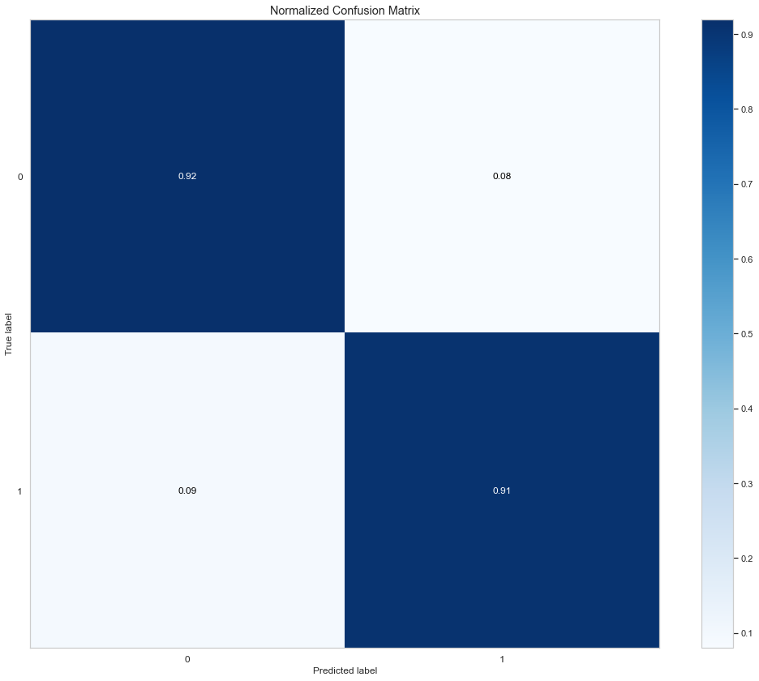

```python
# confusion matrix output
skplt.metrics.plot_confusion_matrix(y_test, predictions, normalize=True)
```

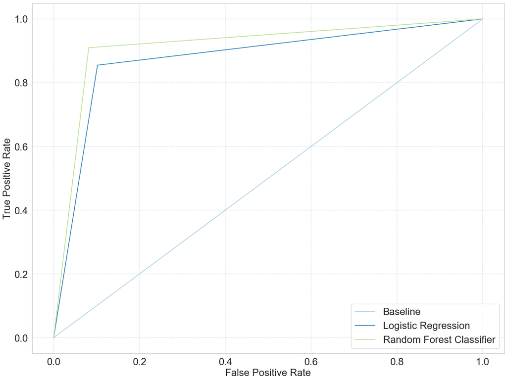

```python
plt.rc('font', size=22)
plt.rc('axes', titlesize=22)
plt.rc('axes', labelsize=22)
plt.rc('xtick', labelsize=22)
plt.rc('ytick', labelsize=22)
plt.rc('legend', fontsize=22)
plt.rc('figure', titlesize=22)

base_probs = [0 for _ in range(len(y_test))]
base_fpr,base_tpr, _ = metrics.roc_curve(y_test, base_probs)
fpr_lr, tpr_lr, _b = metrics.roc_curve(y_test,  prediction_logreg)
fpr_rf, tpr_rf, _a = metrics.roc_curve(y_test,  predictions)
plt.plot(base_fpr,base_tpr,label="Baseline")
plt.plot(fpr_lr,tpr_lr,label="Logistic Regression")
plt.plot(fpr_rf,tpr_rf,label="Random Forest Classifier")
plt.legend(loc=4)
plt.grid(color='b', ls = '-.', lw = 0.25)
plt.xlabel('False Positive Rate')
plt.ylabel('True Positive Rate')
plt.show()
plt.show()
```

Random Forest ROC curve is higher than that for the Logistic Regression ROC curve. Therefore, we can say that RF did a better job of classifying the positive class in the dataset

## Select Model Business Implications

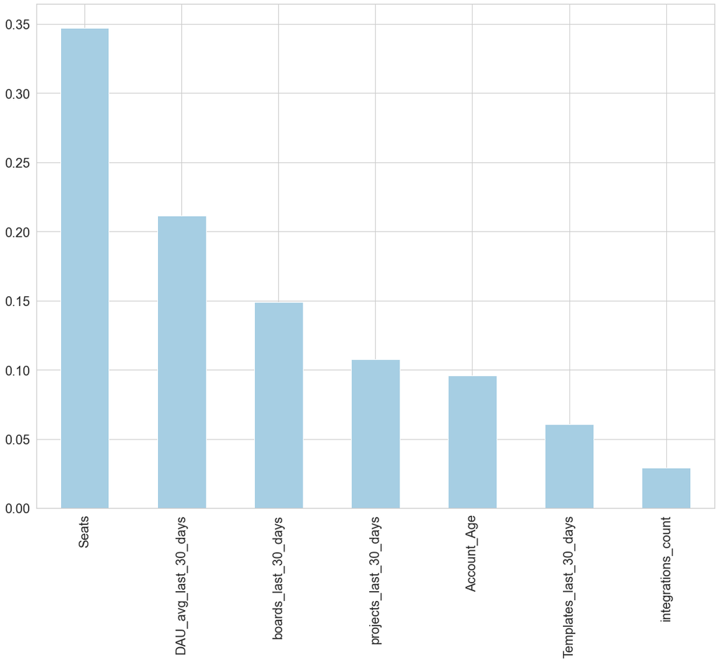

```python
feat_importances = pd.Series(classifier.feature_importances_, index=X.columns)
plt.xticks(fontsize=20)
plt.yticks(fontsize=20)
feat_importances.nlargest(15).plot(kind='bar')
```

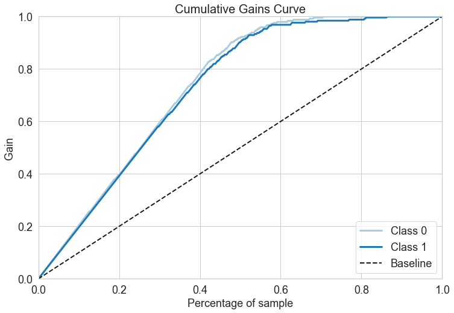

```python
predictions_prob = classifier.predict_proba(X_test)
skplt.metrics.plot_cumulative_gain(
    y_test, predictions_prob, figsize=(12, 8), title_fontsize=20, text_fontsize=18
)
plt.show()
```

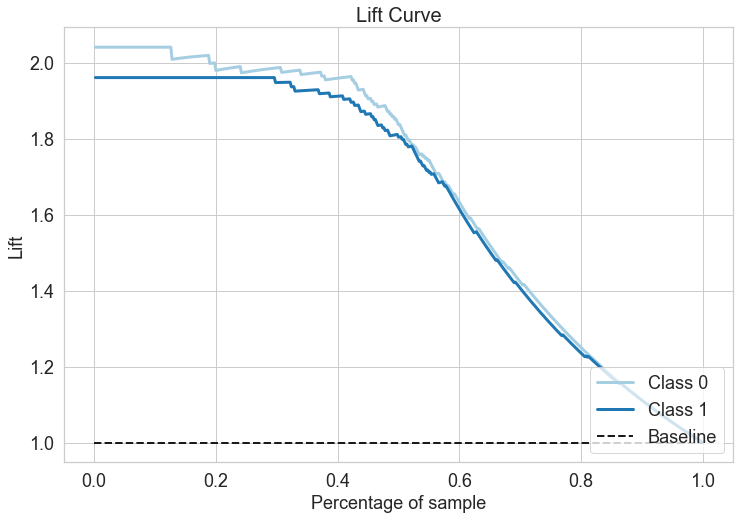

```python
skplt.metrics.plot_lift_curve(
    y_test, predictions_prob, figsize=(12, 8), title_fontsize=20, text_fontsize=18
)
plt.show()
```